# Jupyter-Notebook-101_complete

[figure not shown]

## Jupyter Notebook 101

This workshop is not about teaching you tools. Why? First, we have a varied group ranging from experienced programmers to managers and experts in non-IT areas of the business. Any level I could teach at would be too high for some, or too low for others. Second, tools change with role, location, and time while fundamental concepts are generally applicable and here to stay.

That being said, having a little context about the tools will help orient you for the main lesson ahead.

## What is this?

You are currently working in what is called a "Jupyter Notebook", which is a web document made of "cells" that either contain text, images, tables, etc. (similar to a word processor) or blocks of code that can be run in an interactive Python (or other language) session.

1. First, I will show an example of the text and code cells.
2. Second, I will explain what "interactive" Python is and show some examples.
3. Third, I will share some reasons why Jupyter Notebooks are popular in data science.

#### Example Text Cell

This is a cell that contains text. The text can easily be *styled* in **basic** ways by "marking up" the text using a syntax called "markdown". You can also style text and other content in complex ways if you happen to know HTML.

Try double-clicking on this cell to activate it for editing. Notice how, in markdown, the single asterisk "marks up" italics while the double asterisk "marks up" bold. If you'd like to save your changes and "render" the text, simply type **"shift+enter"** or click the **"Run"** button at the top of the document.

#### Example Code Cell

```python
# This is a cell that contains code - the hashtag indicates that this is a 'comment'
# This cell is also run by typing "shift-enter" or clicking the run button above
1 + 1
```

```
2
```

#### Interactive Python

So what is an interactive Python session? Python is a general-purpose programming language. However, for our use here, you can think of it as being a very powerful and customizable (programmable) calculator. Traditionally, you would operate this calculator from what is called a command line or terminal interface like the one shown below.

[figure not shown]

The user enters commands using one or more lines at a time, and the terminal shows corresponding outputs. Notice how the earlier code cell in the notebook mirrors the snapshot of a terminal session.

#### The Big Picture

You can basically think of Jupyter as a way to "puppeteer" an interactive Python terminal through your web browser. In addition, the interactions are documented and rendered as a web page. This is simplifying a bit, but that's enough detail for our purposes.

[figure not shown]

## What kind of things can we do?

You can also run calculations that require multiple lines of commands by storing **variables** in memory and referencing them in future commands.

```python
# An example of storing a result and then using it in the next command, * is the multiplication operator
first_result = 1 + 1
first_result * 2
```

```
4
```

So far we have seen trivial examples. However, we can also import additional commands ranging from standard mathematical functions to advanced machine learning algorithms.

Behind the scenes, these commands are written in Python by open-source software developers (or you can write your own). When we import a **module**, we are tapping into a particular set of behind-the-scenes code.

One of the great advantages of using Python for data science is the vast amount of open-source code that can be used off-the-shelf or customized to suit a particular analysis or application. In addition, Python modules can even interface with high performance software written in other languages.

#### Math

```python
# Import math module and use the built-in square root command
import math
math.sqrt(4)
```

```
2.0
```

#### Plotting

We can also import modules for plotting data. Below, we will generate a plot with some randomly generated data. Don't worry if you do not understand this code, we are simply demonstrating how figures can be generated within a Jupyter notebook.

```python
import matplotlib.pyplot as plt # a very popular plotting module
import numpy as np # a very popular numerical computing and linear algebra module
```

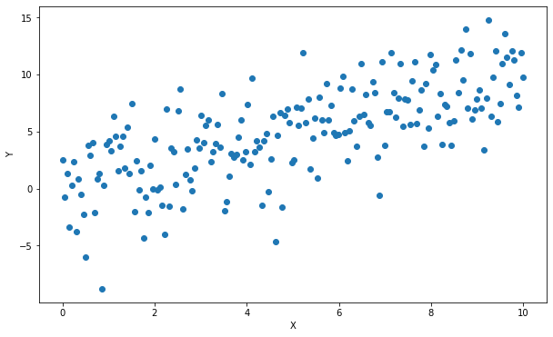

```python
plt.figure(figsize=(10,6))
x = np.linspace(0,10,200)
y = x + 3*np.random.randn(200)
plt.scatter(x, y)
plt.xlabel('X')
plt.ylabel('Y')
plt.show()
```

#### Statistical Modeling

We can then import a module that performs linear regression to predict Y using X. Again, do not worry if you do not follow the commands. This is simply to demonstrate that we can import modeling commands in the same way we imported math and plotting commands.

```python
from sklearn.linear_model import LinearRegression

model = LinearRegression() # This constructs a model
model.fit(x[:,None], y) # This fits the model to the data from above
yhat = model.predict(x[:,None]) # This predicts the y values using the x values
```

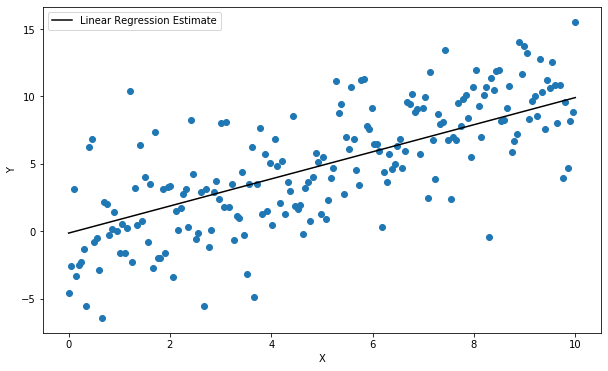

```python
plt.figure(figsize=(10,6))
x = np.linspace(0,10,200)
y = x + 3*np.random.randn(200)
plt.scatter(x, y)
plt.plot(x, yhat, c='k', label='Linear Regression Estimate')
plt.legend()
plt.xlabel('X')
plt.ylabel('Y')
plt.show()
```

## Why use it?

Jupyter Notebooks have become very popular in data science because:

1. They are self-documenting and reproducible.
2. They use a web browser interface, making online computing and sharing easy.
3. They support iterative workflows.